# EDA & Plot

## Explantory data analysis & R color

사용하는 패키지 - plotrix - vioplot - vcd

Barplot

```r
counts = table(state.region)
counts
```

```
## state.region
##     Northeast         South North Central          West
##             9            16            12            13
```

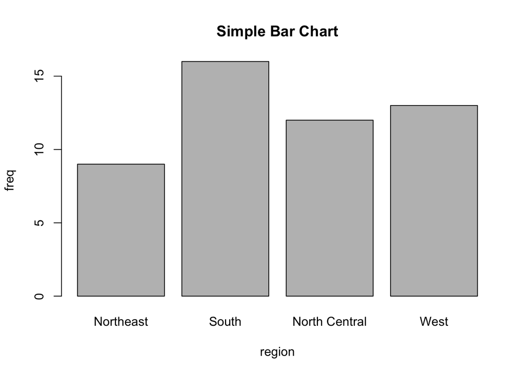

```r
barplot(counts, main = 'Simple Bar Chart', xlab = 'region', ylab = 'freq')
```

```r
mtcars
```

```
##                      mpg cyl  disp  hp drat    wt  qsec vs am gear carb
## Mazda RX4           21.0   6 160.0 110 3.90 2.620 16.46  0  1    4    4
## Mazda RX4 Wag       21.0   6 160.0 110 3.90 2.875 17.02  0  1    4    4
## Datsun 710          22.8   4 108.0  93 3.85 2.320 18.61  1  1    4    1
## Hornet 4 Drive      21.4   6 258.0 110 3.08 3.215 19.44  1  0    3    1
## Hornet Sportabout   18.7   8 360.0 175 3.15 3.440 17.02  0  0    3    2
## Valiant             18.1   6 225.0 105 2.76 3.460 20.22  1  0    3    1
## Duster 360          14.3   8 360.0 245 3.21 3.570 15.84  0  0    3    4
## Merc 240D           24.4   4 146.7  62 3.69 3.190 20.00  1  0    4    2
## Merc 230            22.8   4 140.8  95 3.92 3.150 22.90  1  0    4    2
## Merc 280            19.2   6 167.6 123 3.92 3.440 18.30  1  0    4    4
## Merc 280C           17.8   6 167.6 123 3.92 3.440 18.90  1  0    4    4
## Merc 450SE          16.4   8 275.8 180 3.07 4.070 17.40  0  0    3    3
## Merc 450SL          17.3   8 275.8 180 3.07 3.730 17.60  0  0    3    3
## Merc 450SLC         15.2   8 275.8 180 3.07 3.780 18.00  0  0    3    3
## Cadillac Fleetwood  10.4   8 472.0 205 2.93 5.250 17.98  0  0    3    4
## Lincoln Continental 10.4   8 460.0 215 3.00 5.424 17.82  0  0    3    4
## Chrysler Imperial   14.7   8 440.0 230 3.23 5.345 17.42  0  0    3    4
## Fiat 128            32.4   4  78.7  66 4.08 2.200 19.47  1  1    4    1
## Honda Civic         30.4   4  75.7  52 4.93 1.615 18.52  1  1    4    2
## Toyota Corolla      33.9   4  71.1  65 4.22 1.835 19.90  1  1    4    1
## Toyota Corona       21.5   4 120.1  97 3.70 2.465 20.01  1  0    3    1
## Dodge Challenger    15.5   8 318.0 150 2.76 3.520 16.87  0  0    3    2
## AMC Javelin         15.2   8 304.0 150 3.15 3.435 17.30  0  0    3    2
## Camaro Z28          13.3   8 350.0 245 3.73 3.840 15.41  0  0    3    4
## Pontiac Firebird    19.2   8 400.0 175 3.08 3.845 17.05  0  0    3    2
## Fiat X1-9           27.3   4  79.0  66 4.08 1.935 18.90  1  1    4    1
## Porsche 914-2       26.0   4 120.3  91 4.43 2.140 16.70  0  1    5    2
## Lotus Europa        30.4   4  95.1 113 3.77 1.513 16.90  1  1    5    2
## Ford Pantera L      15.8   8 351.0 264 4.22 3.170 14.50  0  1    5    4
## Ferrari Dino        19.7   6 145.0 175 3.62 2.770 15.50  0  1    5    6
## Maserati Bora       15.0   8 301.0 335 3.54 3.570 14.60  0  1    5    8
## Volvo 142E          21.4   4 121.0 109 4.11 2.780 18.60  1  1    4    2
```

```r
str(mtcars)
```

```
## 'data.frame':    32 obs. of  11 variables:
##  $ mpg : num  21 21 22.8 21.4 18.7 18.1 14.3 24.4 22.8 19.2 ...
##  $ cyl : num  6 6 4 6 8 6 8 4 4 6 ...
##  $ disp: num  160 160 108 258 360 ...
##  $ hp  : num  110 110 93 110 175 105 245 62 95 123 ...
##  $ drat: num  3.9 3.9 3.85 3.08 3.15 2.76 3.21 3.69 3.92 3.92 ...
##  $ wt  : num  2.62 2.88 2.32 3.21 3.44 ...
##  $ qsec: num  16.5 17 18.6 19.4 17 ...
##  $ vs  : num  0 0 1 1 0 1 0 1 1 1 ...
##  $ am  : num  1 1 1 0 0 0 0 0 0 0 ...
##  $ gear: num  4 4 4 3 3 3 3 4 4 4 ...
##  $ carb: num  4 4 1 1 2 1 4 2 2 4 ...
```

```r
head(mtcars)
```

```
##                    mpg cyl disp  hp drat    wt  qsec vs am gear carb
## Mazda RX4         21.0   6  160 110 3.90 2.620 16.46  0  1    4    4
## Mazda RX4 Wag     21.0   6  160 110 3.90 2.875 17.02  0  1    4    4
## Datsun 710        22.8   4  108  93 3.85 2.320 18.61  1  1    4    1
## Hornet 4 Drive    21.4   6  258 110 3.08 3.215 19.44  1  0    3    1
## Hornet Sportabout 18.7   8  360 175 3.15 3.440 17.02  0  0    3    2
## Valiant           18.1   6  225 105 2.76 3.460 20.22  1  0    3    1
```

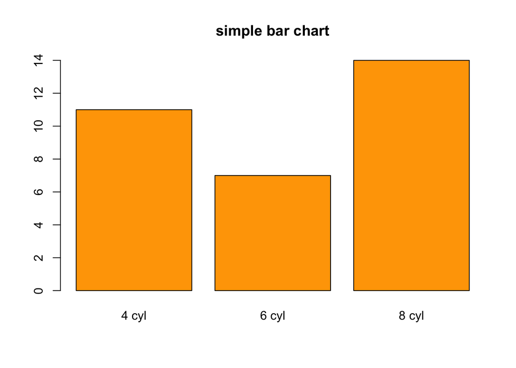

```r
freq.cyl = table(mtcars$cyl)
cyl.name = c("4 cyl", "6 cyl", "8 cyl")
barplot(freq.cyl, main = "simple bar chart", col ="orange", names.arg = cyl.name)
```

Pie Chart - 범주형 변수의 시각화에 파이 차트를 많이 사용 - 파이차트는 pie() 함수를 사용 - 파이차트 위에 범주레벨과 비율을 표시하기 위해 lable 옵션 사용

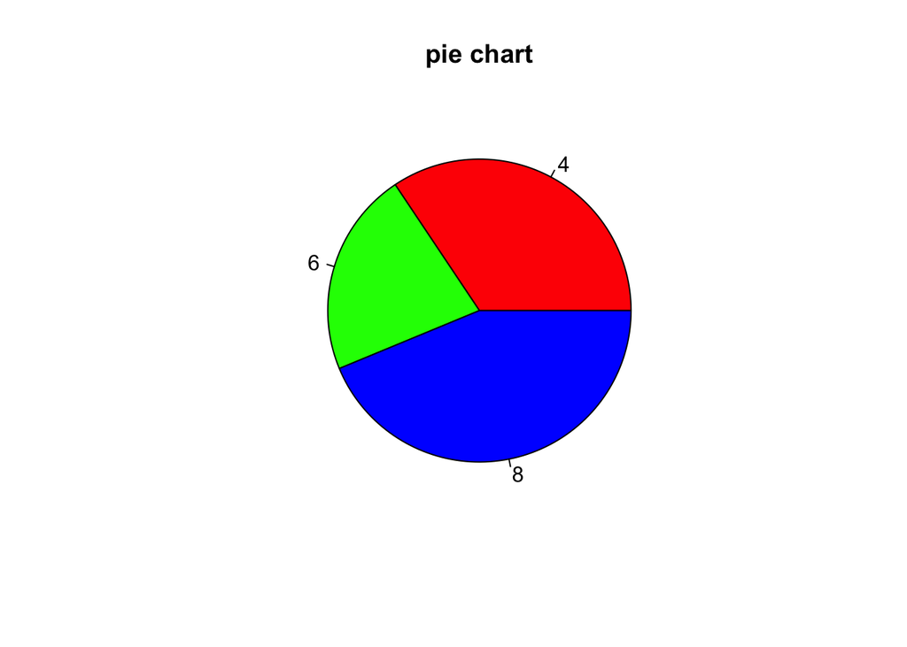

```r
cyl.name2 = paste0(cyl.name, "(", freq.cyl, "%)")
pie(freq.cyl, lables = cyl.name2, col = rainbow(length(freq.cyl)), main = 'pie chart')
```

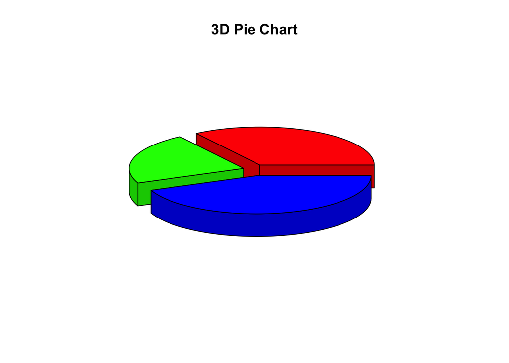

```r
if(!require(plotrix)){install.packages('plotrix'); library(plotrix)}
pie3D(freq.cyl, lables = cyl.name2, explode = 0.1, main = '3D Pie Chart')
```

3D Pie Chart - plotrix() : 3차원 형태의 Pie Chart 생성

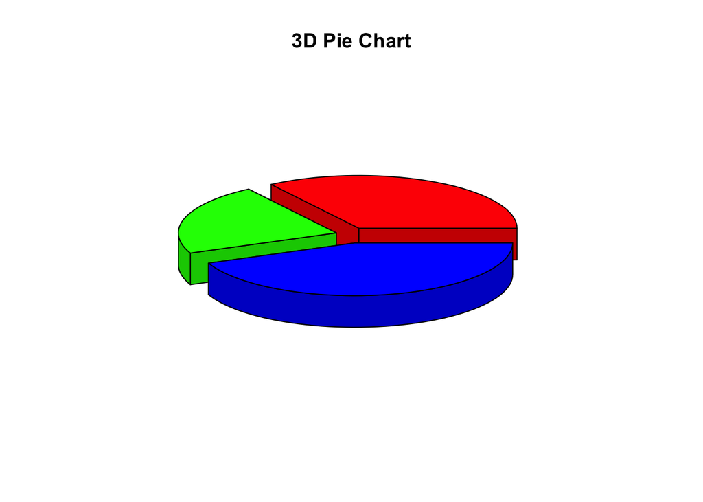

```r
if(!require(plotrix)){install.packages('plotrix'); library(plotrix)}
pie3D(freq.cyl, lables = cyl.name2, explode = 0.1, main = '3D Pie Chart')
```

Fan Plot - fan.plot() : 범주의 레벨 간 비교가 용이함

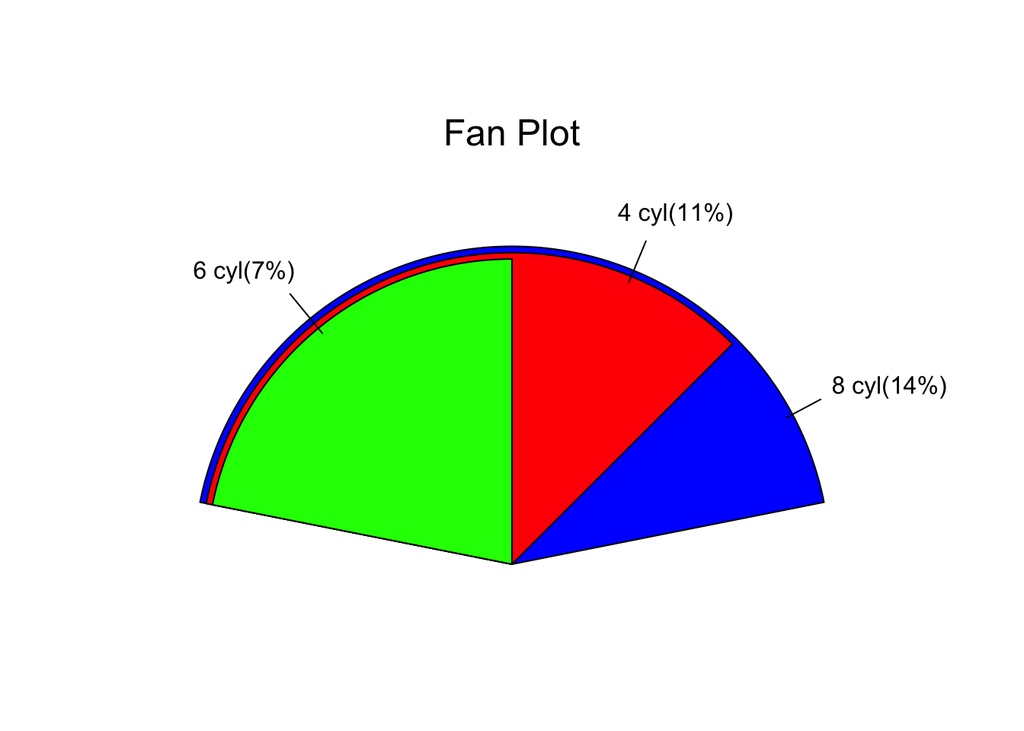

```r
fan.plot(freq.cyl, labels = cyl.name2, main = "Fan Plot")
```

## Frequency of mutivariate variables

### Introduction

- 두개 이상의 범주를 가진 데이터에서 빈도를 분석
- 예: (형액형, 성별), (투약엽, 병증의 개선 정도)
- 빈도 테이블의 작성 시각화
- 빈도테이블의 작성 : xtab 함수 이용
- 시각화 : barplot(), spine() 함수의 이용
- 데이터: 류마티스 관절염에 대한 의학 실험 데이터
- ID, 처치(Treatment), 성별(Sex), 나이(Age), 개선정도(Improved)

```r
if(!require(vcd)){install.packages('vcd'); library(vcd)}
head(Arthritis, n = 3)
```

```
##   ID Treatment  Sex Age Improved
## 1 57   Treated Male  27     Some
## 2 46   Treated Male  29     None
## 3 77   Treated Male  30     None
```

```r
my.table <- xtabs( ~ Treatment + Improved, data = Arthritis)
my.table
```

```
##          Improved
## Treatment None Some Marked
##   Placebo   29    7      7
##   Treated   13    7     21
```

- 빈도분석 : 처치여부와 개선정도의 빈도 분석
- ~Treatment + Improved
- xtab() 함수는 table 변수보다 직관적으로 빈도분석 툴을 제공

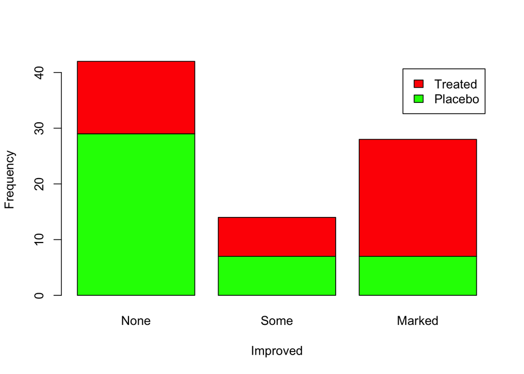

```r
barplot(my.table, xlab = "Improved", ylab = "Frequency",
        legend.text = TRUE, col = c("green", "red"))
```

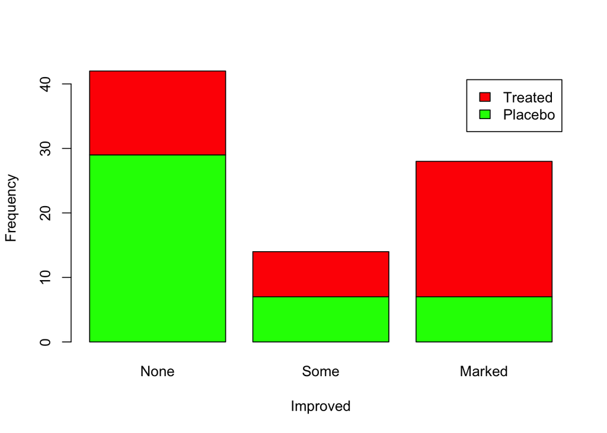

```r
barplot(my.table, xlab = "Improved", ylab = "Frequency",
        legend.text = TRUE, col = c("green", "red"))
```

## Continuous Variables and Visualization

### 소개

- 연속형 자료를 요약하고 시각화
- 연속형 자료의 예: 키, 몸무게, 주가…
- 연속형 자료의 요약치 : 평균, 중앙값, 분위수…
- 연속형 자료의 시각화 도구 : boxplot, 히스토그램, 바이올린 플롯

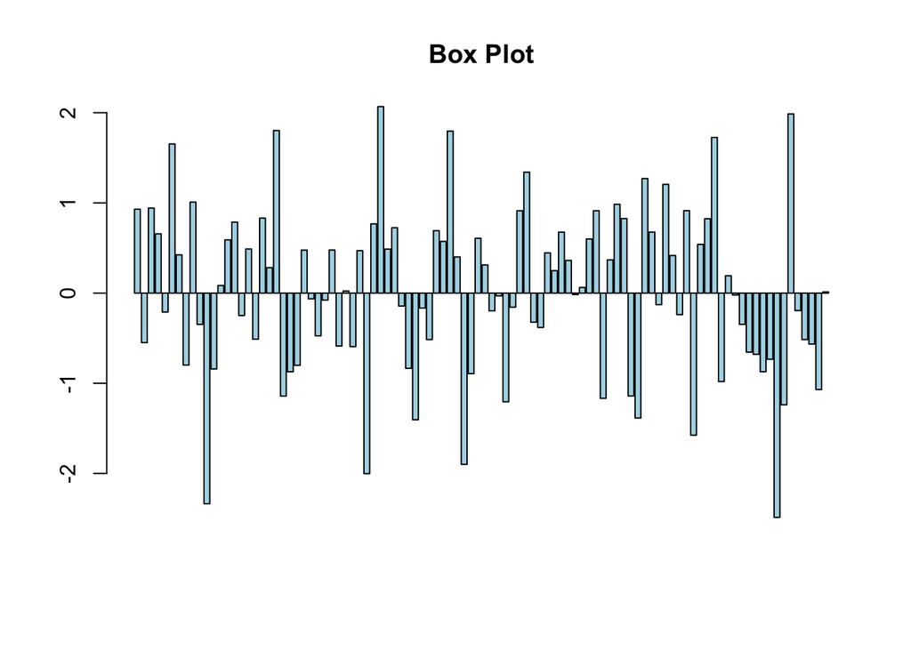

```r
x = rnorm(100)
barplot(x, main = "Box Plot", col = "lightblue")
```

### Histogram

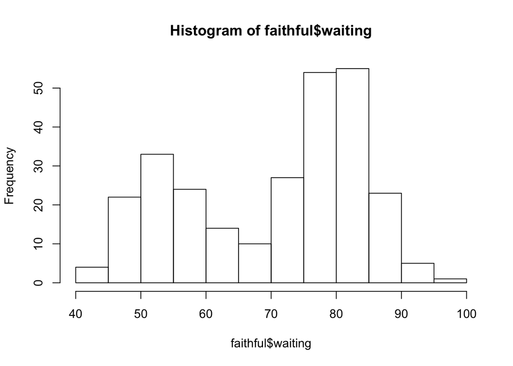

```r
x = faithful$waiting
hist(faithful$waiting, nclass = 8)
```

- hist() 함수는 히스토그램을 생성한다.
- 히스토그램의 형태는 계급구간을 어떻게 설정하는가에 따라 달라 짐
- 주로 nclass에 개수를 입력하여 계급구간을 설정한다
- 정확한 계급구간은 break 옵션을 통해 정의
- 히스토그램의 높이를 확률로 표시하기 위해 probability = T를 사용
- 히스토그램은 연속형 자료의 분포를 보여주는 시각도구

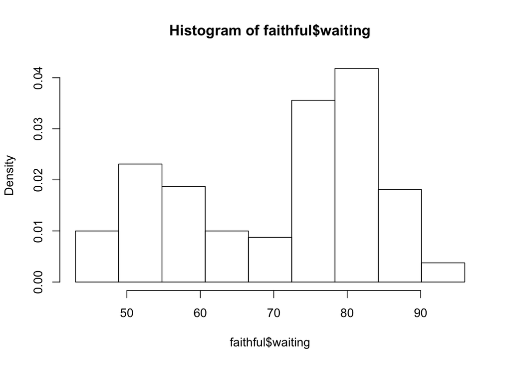

```r
x = faithful$waiting
hist(faithful$waiting, breaks = seq(min(x), max(x),
                                    length = 10), probability = T)
```

- density() 함수를 이용해서 확률밀도함수를 추가할 수 있다.

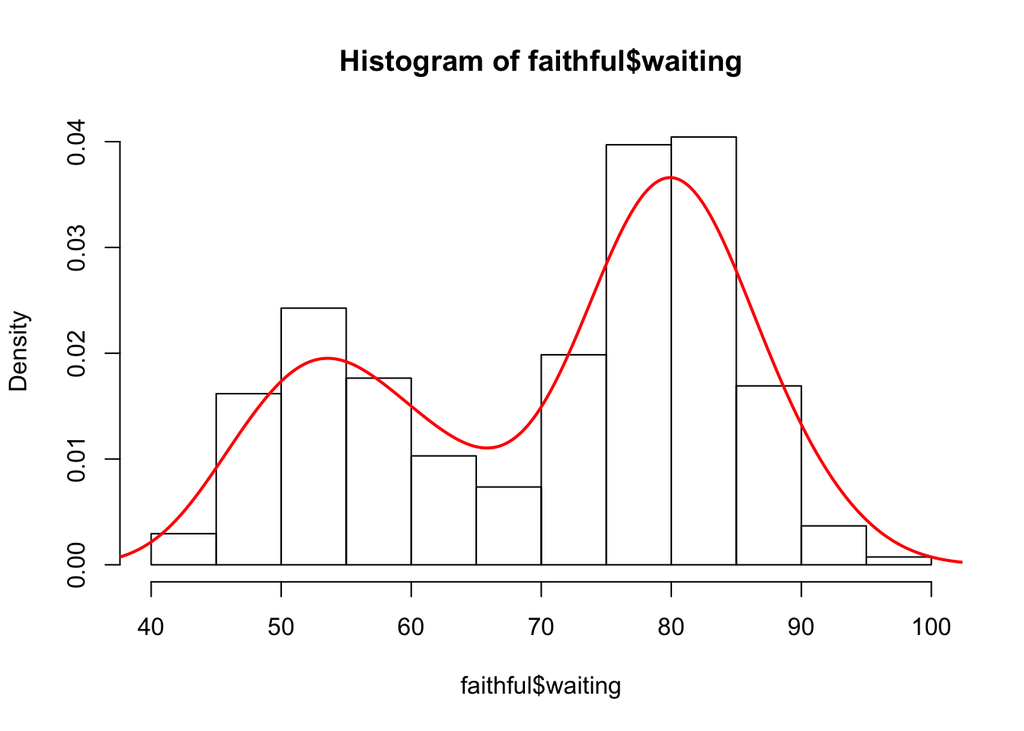

```r
x = faithful$waiting
hist(faithful$waiting, nclas = 10, probability = T)
lines(density(x), col = "red", lwd = 2)
```

### Violin Plot

- violin plot은 boxplot의 장점과 histogram의 장점을 결갑한 시각화

```r
if(!require(vioplot)){install.packages("vioplot"); library(vioplot)}
```

```
## Package 'sm', version 2.2-5.5: type help(sm) for summary information
```

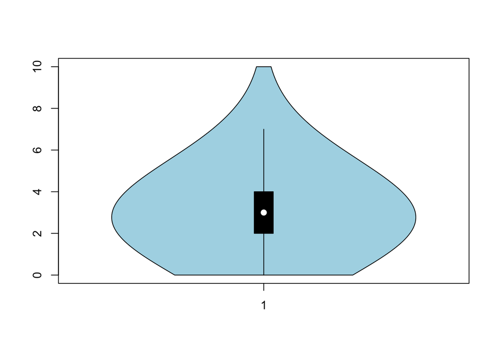

```r
x = rpois(1000, lambda = 3)
vioplot(x, col = 'lightblue')
```

## Visualization for multivatiate Variables

### Multiple Boxplot

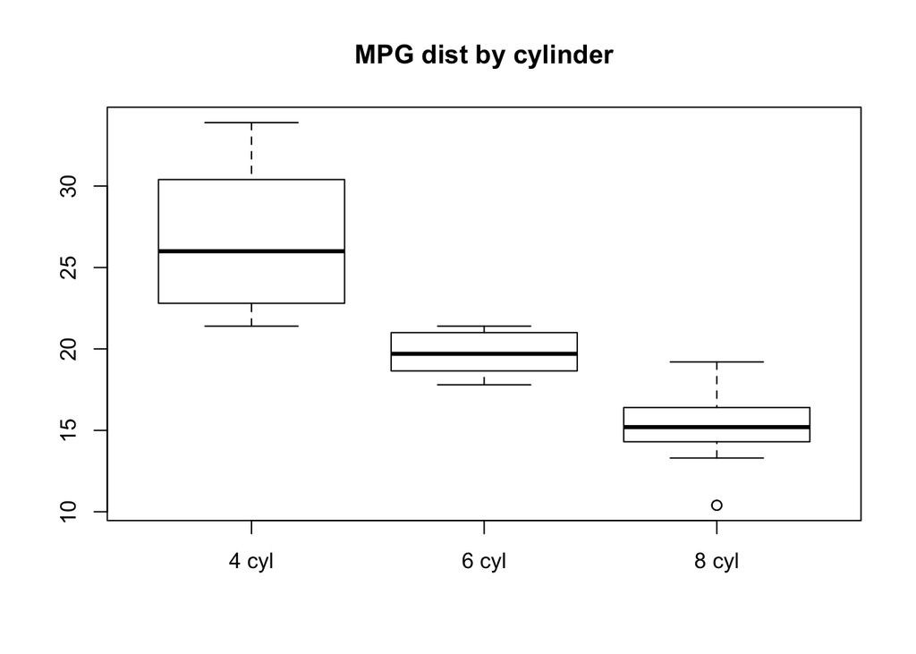

```r
attach(mtcars)
boxplot(mpg~cyl, data = mtcars, names = c('4 cyl', '6 cyl', '8 cyl'),
        main = 'MPG dist by cylinder')
```

### Multiple Histogram

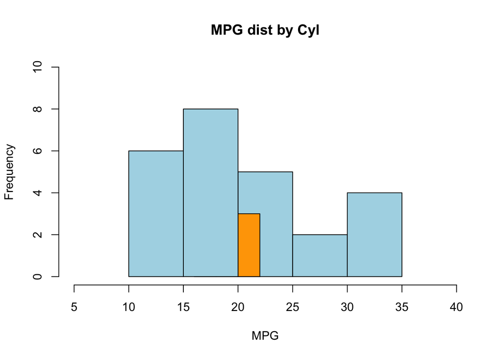

```r
hist(mpg[cyl==4], xlab = 'MPG', main = 'MPG dist by Cyl',
     xlim = c(5, 40), ylim = c(0, 10), col = 'lightblue',
     nclass = trunc(sqrt(length(mpg[cyl==4]))))
hist(mpg[cyl==6], xlab = 'MPG', main = 'MPG dist by Cyl',
     xlim = c(5, 40), ylim = c(0, 10), col = 'orange',
     nclass = trunc(sqrt(length(mpg[cyl==6]))), add = T)
hist(mpg[cyl==8], xlab = 'MPG', main = 'MPG dist by Cyl',
     xlim = c(5, 40), ylim = c(0, 10), col = 'lightblue',
     nclass = trunc(sqrt(length(mpg[cyl==8]))), add = T)
```

### Multiple Histogram 2

- par의 mfrow 옵견을 이용하여 3개의 히스토그램을 수직으로 배열
- xlim 을 맟춰야 데이터이 중심비교가 용이 함

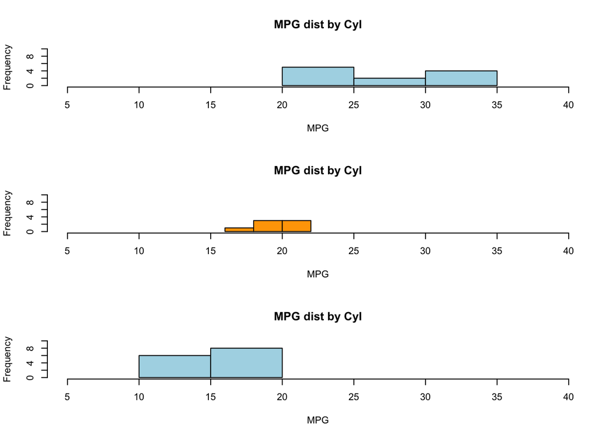

```r
opar <- par(no.readonly = TRUE)
par(mfrow = c(3,1))
hist(mpg[cyl==4], xlab = 'MPG', main = 'MPG dist by Cyl',
     xlim = c(5, 40), ylim = c(0, 10), col = 'lightblue',
     nclass = trunc(sqrt(length(mpg[cyl==4]))))
hist(mpg[cyl==6], xlab = 'MPG', main = 'MPG dist by Cyl',
     xlim = c(5, 40), ylim = c(0, 10), col = 'orange',
     nclass = trunc(sqrt(length(mpg[cyl==6]))))
hist(mpg[cyl==8], xlab = 'MPG', main = 'MPG dist by Cyl',
     xlim = c(5, 40), ylim = c(0, 10), col = 'lightblue',
     nclass = trunc(sqrt(length(mpg[cyl==8]))))
```

```r
par(opar)
```

### Multiple Densities

- 확률밀도함수를 한번에 표현할 수 있음

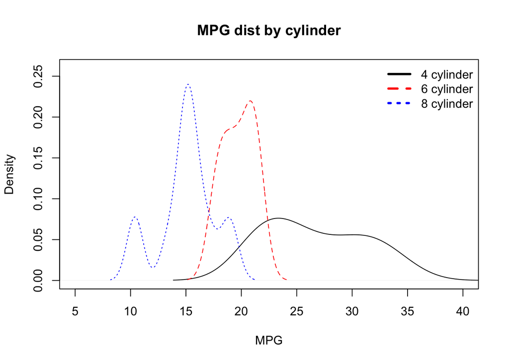

```r
plot(density(mpg[cyl==4]), xlab = "MPG", main = "MPG dist by cylinder",
     xlim = c(5, 40), ylim = c(0., 0.26))

lines(density(mpg[cyl==6]), col = "red", lty = 2)
lines(density(mpg[cyl==8]), col = "blue", lty = 3)
legend("topright", paste(c(4,6,8), "cylinder"),
       col = c("black", "red", "blue"),
       lty = c(1,2,3), lwd = 3, bty = "n")
```

> 실습
- 부모님의 안전벨트 착용 유무와 자녀의 안전벨트 착용 유무의 비교 예제

```r
tmp <- c("buckled", "unbuckled")
belt <- matrix(c(58, 2, 8, 16), ncol = 2,
               dimnames = list(parent = tmp, child = tmp))
belt
```

```
##            child
## parent      buckled unbuckled
##   buckled        58         8
##   unbuckled       2        16
```

- 부모의 안전벨트 착용이 자식간의 안전벨트 착용에 영향을 준다는 것을 시각화

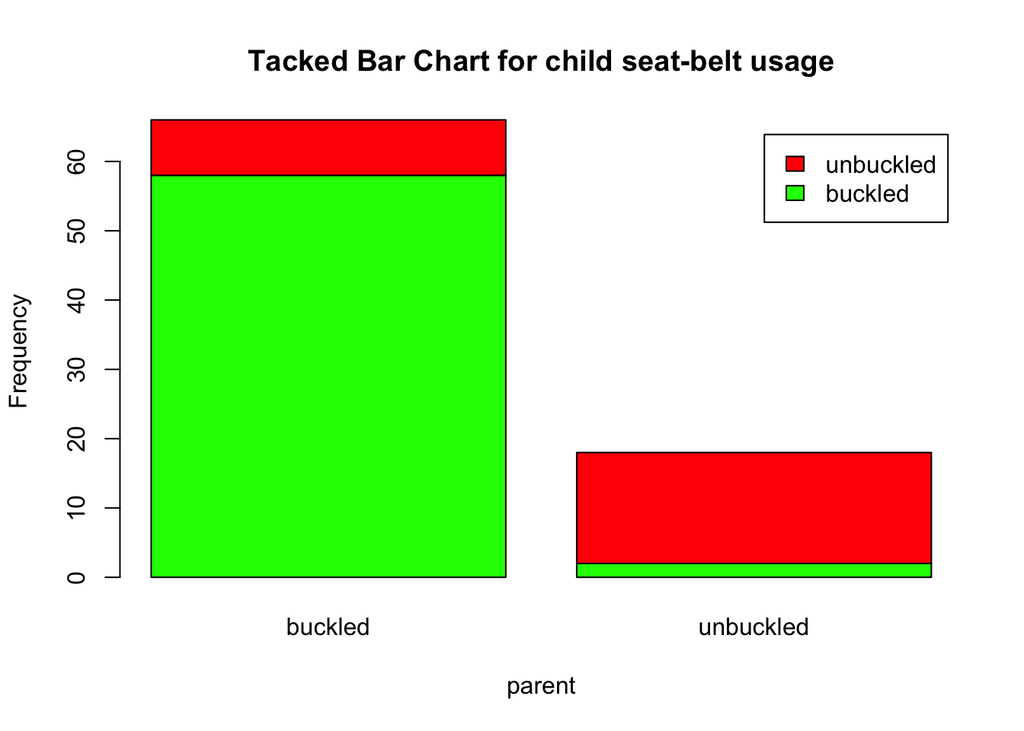

```r
barplot(t(belt), main = "Tacked Bar Chart for child seat-belt usage",
        xlab = "parent", ylab = "Frequency", legend.text = T,
        col = c("green", "red"))
```

### R Colors

- 16진법 표기글 사용 (0~9, A~F)
- 기본적으로 빨간색, 초록색, 파란색을 지정하며, 16진법으로 2개씩 표현 (즉, 기봄색상 별로 각각 256개로 표현할 수 있음(#rrggbb))
- 256 x 256 x 256 = 2^24개의 색상 표현 : 24 bit colors
- 또한, 24 bit colors에 투명도(256 level)를 추가하면 32 bit color system이 됨 (#rrggbbaa)

#### colors()

- Basic Color

```r
head(colors())
```

```
## [1] "white"         "aliceblue"     "antiquewhite"  "antiquewhite1"
## [5] "antiquewhite2" "antiquewhite3"
```

```r
tail(colors())
```

```
## [1] "yellow"      "yellow1"     "yellow2"     "yellow3"     "yellow4"
## [6] "yellowgreen"
```

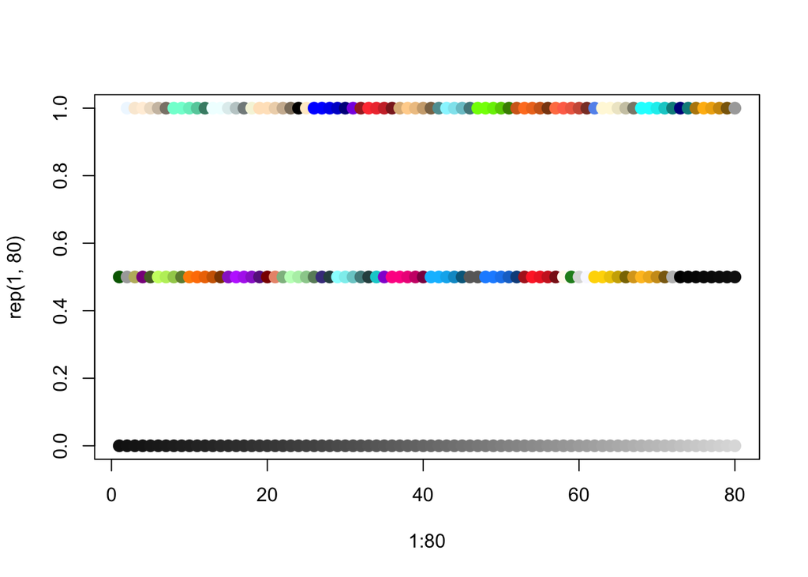

```r
mycol <- colors()
plot(1:80, y=rep(1,80), col = mycol[1:80], cex = 2, pch = 20, ylim = c(0,1))
points(1:80, y=rep(0.5,80), col = mycol[81:160], cex = 2, pch = 20)
points(1:80, y=rep(0,80), col = mycol[161:240], cex = 2, pch = 20)
```

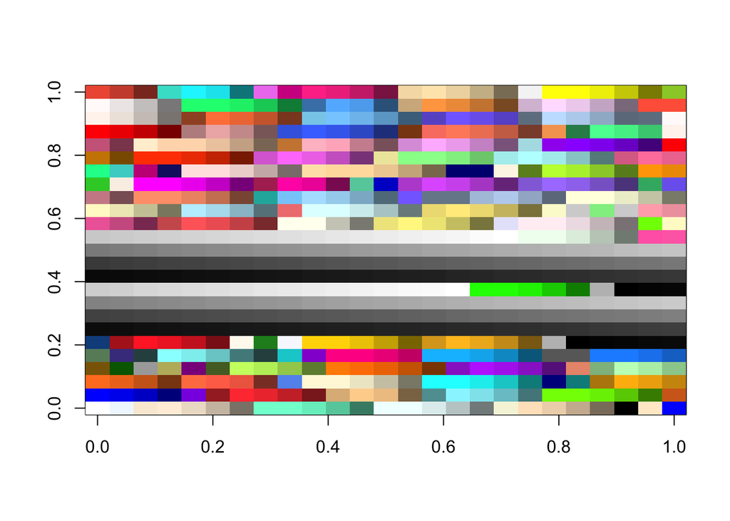

```r
mycol <- colors()
image(matrix(1:25^2, 25, 25), col = mycol)
```

### RGB Function

- rgb(red, green, blue, maxColorValue, alpha)
- red, greem blue : 기본으로 0 ~ 1 사이의 값을 사용
- macColorValue = 255 으로 세팅하면 0 ~ 255 사이의 값으로 사용할 수 있음
- alpha : opaciry(투명도)

```r
rgb(10, 4, 23, maxColorValue = 255, alpha = 10)
```

```
## [1] "#0A04170A"
```

```r
col2rgb("lightblue")
```

```
##       [,1]
## red    173
## green  216
## blue   230
```

### Hue Color System

- 색상들은 콘 모양으로 볼 수 있음
- 바깥쪽으로 갈수록 채도가 높은 색
- 위쪽으로 갈수록 밝기는 증가 함

#### hcl function

- hcl(h, c, l, alpah)
- h: colors(색상), c: saturation(채도), l: brightness(밝기), alpha: Opaity(투명도)
- h [0, 360]: 0~120(red), 120-240(green), 240-360(blue)
- i [0, 100]: alpah [0, 1]
- c의 범위는 h와 l의 값에 따라 변한다

```r
hcl(h = 0, c = 35, l = 85, alpha = 0.1)
```

```
## [1] "#FFC5D01A"
```

#### hsv function

- hsv(h, c, v, alpah)
- h: colors(색상), c: saturation(채도), v: brightness(밝기), alpha: Opaity(투명도)
- h, s, v, alpha [0,1]

```r
hsv(0.3, 0.5, 0.1, alpha = 0.4)
```

```
## [1] "#0F1A0D66"
```

### grDevices, colorRamps Packages

- cm.colors, topo.colors, terrain.colors, heat.colors, rainbow
- cm, topo,errain, heat : n(색상의 수), alphar(투명도)

```r
#heat.colors(4, alpah = 0.1)
topo.colors(4, alpha = 0.1)
```

```
## [1] "#4C00FF1A" "#00E5FF1A" "#00FF4D1A" "#FFFF001A"
```

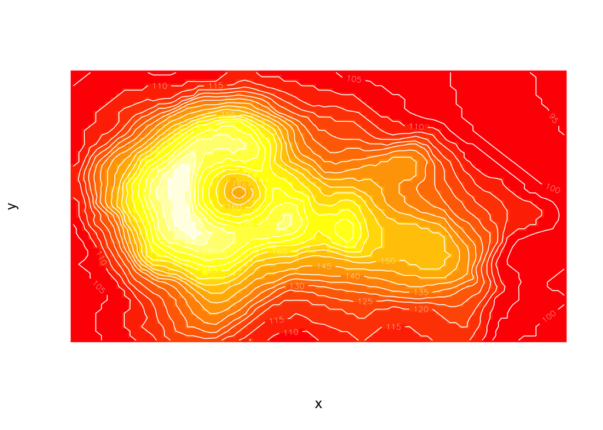

```r
x <- 10 * (1:nrow(volcano))
y <- 10 * (1:ncol(volcano))
image(x, y, volcano, col = heat.colors(20, alpha = 1), axes = FALSE)
contour(x, y, volcano, levels = seq(90, 200, by = 5),
        add = T, col = "white")
```

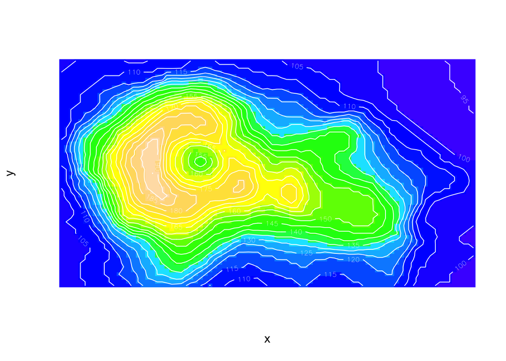

```r
x <- 10 * (1:nrow(volcano))
y <- 10 * (1:ncol(volcano))
image(x, y, volcano, col = topo.colors(20, alpha = 1), axes = FALSE)
contour(x, y, volcano, levels = seq(90, 200, by = 5),
        add = T, col = "white")
```

- rainbow colors는 hsv color system을 기반으로 함
- n (색상의 수), s(채도), v(명도), start(h의 시작값), end(h의 끝값), alpha(투명도)
- 시작값과 끝값의 범위 : 0 ~ 1

```r
rainbow(5, s = 0.4, v = 0.3, start = 0, end = 0.05, alpha = 1)
```

```
## [1] "#4D2E2EFF" "#4D302EFF" "#4D322EFF" "#4D352EFF" "#4D372EFF"
```